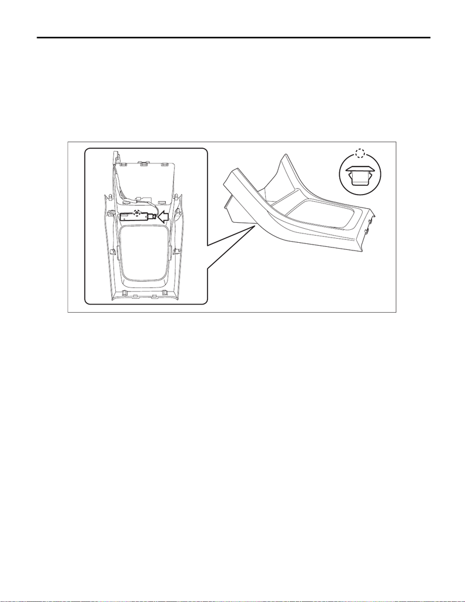

SL-92

Keyless Access Indoor Antenna

SECURITY AND LOCKS

29.Keyless Access Indoor Antenna

A: REMOVAL

1. FRONT ANTENNA

1) Disconnect the ground cable from battery. <Ref. to NT-5, BATTERY, NOTE, Note.>

NOTE:

For models other than STI model, disconnect the ground terminal from battery sensor.

2) Remove the cover - shift lever. <Ref. to EI-67, REMOVAL, Console Box.>

3) Disconnect the connector and remove the front antenna assembly - interior.

2. CENTER ANTENNA

CAUTION:

<Ref. to AB-9, CAUTION, General Description.>

• The airbag system is fitted with the airbag power supply. After disconnecting the battery ground

cable, the airbag may operate if you do not wait for 60 seconds before starting the service of airbag

system.

1) Disconnect the ground cable from battery. <Ref. to NT-5, BATTERY, NOTE, Note.>

NOTE:

For models other than STI model, disconnect the ground terminal from battery sensor.

2) Remove the rear seat cushion assembly. <Ref. to SE-29, REMOVAL, Rear Seat.>

SL-01601

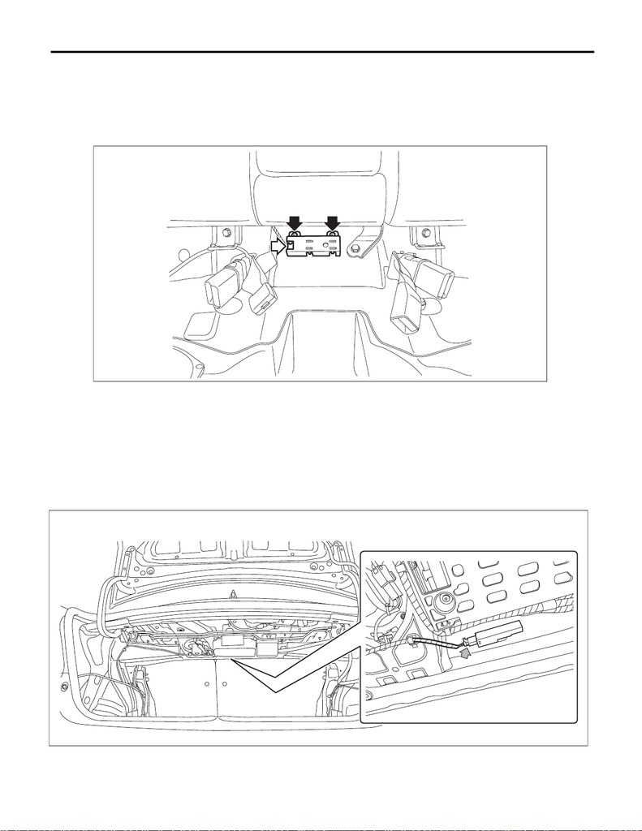

SL-93

Keyless Access Indoor Antenna

SECURITY AND LOCKS

3) Remove the center antenna assembly - interior.

NOTE:

Do not remove the antenna assembly from the cover. If removed, the antenna assembly and cover mounting

becomes loose, causing abnormal noises.

(1) Disconnect the connector.

(2) Remove the screw, and remove the center antenna assembly - interior.

3. REAR ANTENNA

1) Disconnect the ground cable from battery. <Ref. to NT-5, BATTERY, NOTE, Note.>

NOTE:

For models other than STI model, disconnect the ground terminal from battery sensor.

2) Disconnect the connector and remove the rear antenna assembly - interior.

NOTE:

Do not remove the antenna assembly from the cover. If removed, the antenna assembly and cover mounting

becomes loose, causing abnormal noises.

SL-01602

Sl-02878

[figure not shown]

SL-94

Keyless Access Indoor Antenna

SECURITY AND LOCKS

B: INSTALLATION

1. FRONT ANTENNA

1) Install the front antenna assembly - interior.

2) Install the cover - shift lever. <Ref. to EI-68, INSTALLATION, Console Box.>

3) Connect the battery ground terminal. <Ref. to NT-5, BATTERY, NOTE, Note.>

NOTE:

For models other than STI model, connect the ground terminal to battery sensor.

2. CENTER ANTENNA

1) Install the center antenna assembly - interior.

2) Install the rear seat cushion assembly. <Ref. to SE-33, INSTALLATION, Rear Seat.>

3) Connect the battery ground terminal. <Ref. to NT-5, BATTERY, NOTE, Note.>

NOTE:

For models other than STI model, connect the ground terminal to battery sensor.

3. REAR ANTENNA

1) Install the rear antenna assembly - interior.

2) Connect the battery ground terminal. <Ref. to NT-5, BATTERY, NOTE, Note.>

NOTE:

For models other than STI model, connect the ground terminal to battery sensor.

C: INSPECTION

1) Check the setting by performing Keyless access system check using the Subaru Select Monitor. <Ref. to

KPS(diag)-38, OPERATION, Keyless Access System Check.>

2) Disconnect the Subaru Select Monitor. Operate the touch sensor of the door outer handle to check if door

lock operates.

3) If the system does not operate normally as the result of inspection, refer to “General Diagnostic Table” of

the “KEYLESS ACCESS WITH PUSH BUTTON START SYSTEM (DIAGNOSTICS)” section. <Ref. to

KPS(diag)-111, KEYLESS ACCESS SYSTEM, INSPECTION, General Diagnostic Table.>